# Introduction to cellcount - Draft vignette

Tyler E. Harman (Consolidated Safety Services (Contracted to NOAA NCCOS), Fairfax, VA 22031, USA) , Mark W. Vandersea (National Oceanic and Atmospheric Administration, National Centers for Coastal Ocean Science, Beaufort, NC 28516, USA) , Kaytee Pokrzywinski, PhD (National Oceanic and Atmospheric Administration, National Centers for Coastal Ocean Science, Beaufort, NC 28516, USA)  
2024-03-18

# Summary:

The *cellcount* package provides a simple approach to quantifying bacteria and cyanobacteria *via* fluorescence microscopy. Microbial enumeration is an important tool for validating new methods and critical to assess potential ecological changes. However, standard manual microbial enumeration is time-consuming and notoriously difficult due to large colonies, filaments, and dense biomats. Conventional counting methods like microscopy require specialized expertise and are error prone due to variations between microscopists. Additionally, other methods of counting cells or particles (i.e. Coulter counter, flow cytometer, etc.) are not suitable for filamentous or colonial morphotypes that can clog flow cells and apertures. Here, we outline a new open-source package, *cellcount*, a continuation of the report outlined in (Pokrzywinski, Boyd, and Smith 2019) and designed in the R computing language, to quickly and accurately count various microbial morphotypes. With this open source package, fluorescent microscope images can be analyzed to generate particle counts and quantify overall cell density from samples at a rapid speed with the accuracy of comparable conventional counting methods. Furthermore, additional tools are presented in this package using [R Shiny](https://cran.r-project.org/package=shiny) (Chang et al. 2022) interfaces to demonstrate ease-of-use for researchers not familiar with the R environment. All materials outlined in this article, along with tutorials, can be found on NOAA’s National Center for Coastal Ocean Science Harmful Algal Bloom Forecasting (NOAA NCCOS HAB-F) [GitHub.](https://github.com/orgs/HABF-SDI-NCCOS-NOAA/repositories)

# Getting started:

*cellcount* is an open-source R package for enumerating particles in fluorescent microscopy images distributed by NOAA NCCOS HAB-F on GitHub and uses components in the RStudio IDE program. It is advised to use both the latest version of R and RStudio before beginning.

To get started with *cellcount*, make a local clone of the repository using programs like [GitHub Desktop](https://desktop.github.com/). Once cloned, open the R project file and install the package locally by selecting ‘build’ and ‘install package’, or use the shortcut Ctrl+Shift+B (Cmd+Shift+B for MacOS users). Once the *cellcount* package is installed, the following code can be used to bring *cellcount* into the R environment:

```r
library(cellcount)
```

In addition, the following packages are required to use functions within *cellcount*:

- *EBImage* (Pau et al. 2010)
- *tiff* (Urbanek and Johnson 2022)
- *pixmap* (Bivand, Leisch, and Maechler 2021)
- *raster* (Hijmans et al. 2023)
- *beepr* (Baath and Dobbyn 2018)

*EBImage* uses the [Bioconductor](http://bioconductor.org) development software system while the remaining packages use the CRAN server built within R. Use the following code to install and load the packages into the R environment before starting:

```r
if (!require("EBImage")) {
  BiocManager::install("EBImage")
}
library(EBImage)

library(tiff)
library(pixmap)
library(raster)
library(beepr)
```

# Setting up directories/reading files:

After the basic supporting packages have been installed, an empty data frame can be generated to record resulting count data from the *cellcount* package using the following code:

```r
Demo.Results <- data.frame(Image_File_Name = character(0), Cell_Count = numeric(0))
```

In order to appropriately save files from the *cellcount* analysis, some directories will be required; one for saving the unique color label images and another for CSV files. Please note that directory addresses will be different based on operating system and location. It is recommended to use a dedicated directory for *cellcount* results:

```r
savdir <- ("C:/file path for saving CSV data")
image_savdir <- ("C:/file path for saving converted images")
```

Next, images that are of interest will need to read into the R environment using the following code. This example uses ‘tif’ images of *Microcystis* sp. that are provided within the *cellcount* package:

```r
images <- list.files("./cellcount_files_HABF/inst/extdata/test_images/Microcystis_F192_40x/", pattern = "tif", full.name = T)
images_names <- list.files("./cellcount_files_HABF/inst/extdata/test_images/Microcystis_F192_40x/", pattern = "tif", full.name = F)
```

In addition, users can assign additional identifications to each file for easy organization, as shown here:

```r
file_name<-paste0("F192_")
```

Images from the assigned directory can now be “read” into the environment for analysis. The following code outlines this step using the *readTIFF* function from the *tiff* package. In addition, images will need to be re-oriented as the *readTIFF* function uploads images in a portrait format. The *aperm* function shown below re-orients the uploaded image to a landscape format:

```r
imgNames <- paste0(file_name, images_names)
read_images <- lapply(images, readTIFF)
img_transposed <- lapply(read_images,aperm,c(2,1,3))
names(images) <- imgNames
```

# Beginning the conversion process:

Once images are within the R environment, the process to quantify particles within an image can begin. First, begin by converting 24-bit images into 8-bit images using the *greyscale* function (see photo below). This function also has a built-in numerical contrast adjustment that end-users can change:

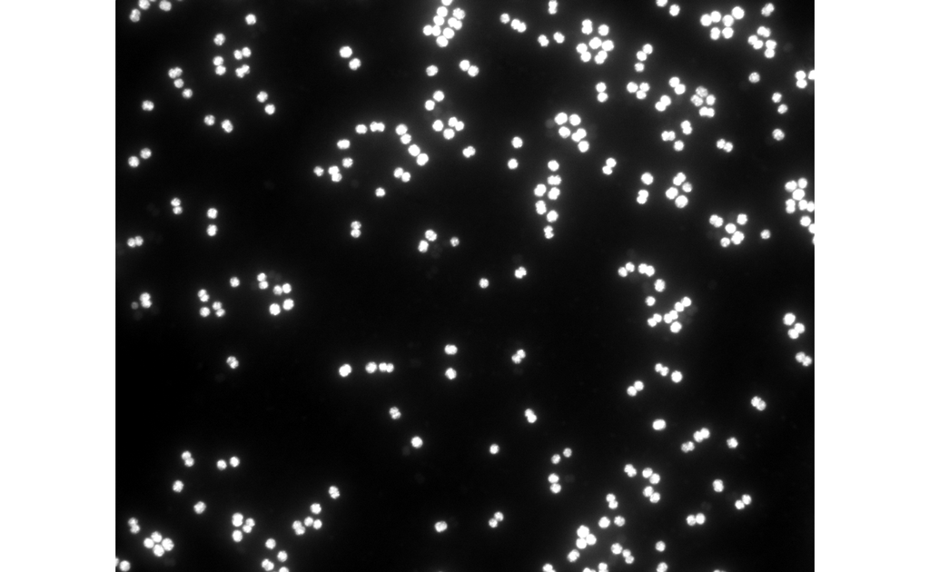

Figure 1: Converted greyscale image of *Microcystis* sp.

```r
grey_images <- lapply(img_transposed, greyscale, contrast = 1)
display(grey_images[[5]])
```

The *mapped* function turns the converted 8-bit image into a data matrix. An additional function to determine the median intensity of each image is also used. From this, users can add a numerical buffer on top of the determined median intensity, giving a more accurate approach to separating the background intensity from the intensity of cells within each image. For example, if an image has a median intensity of 0.05, with a numerical buffer of 0.2, the threshold is equal to 0.25. Any pixel within the image below 0.25 will be omitted from the matrix and assigned a value of zero.

```r
img1<-lapply(grey_images,mapped_avg)
pre_adj<-median(img1[[5]])
main_adj<-pre_adj+0.2
imagesMapped <- lapply(grey_images, mapped, threshold = main_adj)
```

Before images can be analyzed with batch processing, it is encouraged to visually assess image results and determine if fine adjustments need to be made. This could include adjusting the threshold from the *mapped* function, the contrast from the *greyscale* function (if used), or could involve making adjustments to the *single_cell_convert* or *filamentous_convert* functions, such as the width and height of the rectangular window, the pixel area threshold (i.e., removes cells or other objects under a certain pixel area), or the tolerance and ‘ext’ variables. Observe initial results as indicated below and make adjustments where necessary:

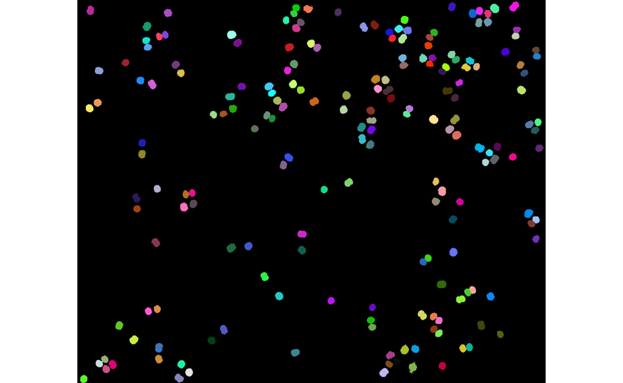

Figure 2: A converted color-label image of *Microcystis* sp.

```r
imagesConverted <- single_cell_convert(imagesMapped[[5]], w = 10, h = 10, offset = 0.001, areathresh = 250, tolerance = 0.8, ext = 1)
final_img <- count_images(imagesConverted, normalize = T, removeEdgeCells = T)
display(final_img)
```

# Analysis of images for producing count data:

Once necessary adjustments have been made, the following for-loop is used to interactively process batch images of interest. In this example, using the provided demo *Microcystis* sp. images, the for-loop uses the *single_cell_convert* function to produce unique color labels on cells within an image and to produce a final image showcasing these labels using the *count_images* function. Finally, *count_cells* is used to count the number of unique color labels (i.e., cells or particles). Code has also been integrated in the for-loop to add these count results to the ‘Demo.Results’ data frame made earlier, and to save each unique color label image to the “image_savdir” directory:

```r
for (z in 1:length(images)) {
  imagesConverted <- single_cell_convert(imagesMapped[[z]], w = 10, h = 10, offset = 0.001, areathresh = 250, tolerance = 0.8, ext = 1)
  final_img <- count_images(imagesConverted, normalize = T, removeEdgeCells = T)
  count <- count_cells(imagesConverted)
  Demo.Results[nrow(Demo.Results) + 1, ] <- c(imgNames[[z]], count)
  analyzed_image <- paste0(sub(".tif", replacement = "", x = imgNames[z]), "_analyzed.tiff")
  writeImage(final_img, files = paste0(image_savdir, analyzed_image),compression=c("LZW"))
}
```

In same cases, some images that were initially taken may be too poor of quality or contain high background fluorescence, among other errors that may arise. The following code analyzes outliers from the produced data, within a range of two standard deviations above and below the median. The *outlier_detect* function tags which images are out of this range and dictates a warning within our data frame, which is shown below. This alerts the end-user to investigate the error further where re-imaging a sample may be necessary:

```r
Demo.Results$Cell_Count<-as.numeric(Demo.Results$Cell_Count)
Demo.Results$within_outlier_range<-outlier_detect()
Demo.Results
```

```
                Image_File_Name Cell_Count within_outlier_range
1  F192_Microcystis_Demo_01.tif        190                 TRUE
2  F192_Microcystis_Demo_02.tif        183                 TRUE
3  F192_Microcystis_Demo_03.tif        233                 TRUE
4  F192_Microcystis_Demo_04.tif        214                 TRUE
5  F192_Microcystis_Demo_05.tif        190                 TRUE
6  F192_Microcystis_Demo_06.tif        219                 TRUE
7  F192_Microcystis_Demo_07.tif        208                 TRUE
8  F192_Microcystis_Demo_08.tif        223                 TRUE
9  F192_Microcystis_Demo_09.tif        221                 TRUE
10 F192_Microcystis_Demo_10.tif        220                 TRUE
```

In order to calculate cell density of these images, the *cell_density* function can be implemented, using equations from (Wetzel and Likens 2000). The output results need to then be converted to a cell density variable, where it can be added to the ‘Demo.Results’ data frame using the following code:

```r
cell.total <- as.numeric(Demo.Results$Cell_Count)
cell.total <- sum(cell.total)
Demo.Results[nrow(Demo.Results) + 1, ] <- c("Cell Total", cell.total," ")
```

Calculating cell density requires multiple values. End-users will need the following information to precisely calculate this value:

- Total counts (generated previously using this package)
- Height of camera field of view (μm)
- Width of camera field of view (μm)
- Total number of images analyzed
- Filtration area (mm<sup>2</sup>)
- Volume filtered per image (mL)
- Total sample volume (mL)

Camera field of view (FOV - mm<sup>2</sup>) is an important variable calculated from image height and image width. Image height and width are variables that are taken from dimensions disseminated by your microscope camera’s manufacturer. Please refer to their documentation to calculate your FOV variable correctly.

With the variables calculated, the following code uses these variables to calculate cell density and adds the data into the ‘Demo.Results’ data frame:

```r
cell.den <- cell_density(cell.total, FOV = 0.0726, images = 10, filtration.area = 213.8, volume = 1, total.volume = 5)
cell.den <- round(cell.den,2)
Demo.Results[nrow(Demo.Results) + 1, ] <- c("Cell Density", cell.den," ")
```

The average number of cells per image can also be calculated, as well as cells per mL using the following code. Note that ‘cell.av’ calculation must contain the number of images the end-user has analyzed (excluding poor quality images and outliers), and the ‘cell.mL’ must be divided by the total volume from the original sample where the filtered subsample was aliquotted from:

```r
cell.av<-(cell.total/10) #change this via total number of images
Demo.Results[nrow(Demo.Results) + 1, ] <- c("Imaging Average",cell.av," ")

cell.mL<-(cell.den/5) #change this via total volume
cell.mL <- round(cell.mL,2)
Demo.Results[nrow(Demo.Results) + 1, ] <- c("Total Volume Cell per mL",cell.mL," ")
```

Finally, the following code can be used to export the finalized data frame to a .csv file to the pre-determined save directory:

```r
write.csv(Demo.Results, paste0(savdir, "/F192_Test counts.csv"))
```